# Analyznig telemetry data in R: spatial formatting & trajectories

James E Paterson (jamespaterson@trentu.ca)

2018-04-02

## Introduction

I will use a simulated data set to demonstrate basic movement analyses in R for telemetry data.

Outline

1. Simulate data and format for spatial analyses
2. Create & manipulate trajectories

## 1. Load data and format for spatial analyses

Before we load data into the workspace, load the R packages we will use.

```r
# Load required packages
library(sp) # Formating and using spatial objects
library(scales) # Will help with transparency in plots we make
library(adehabitatLT) # Constructing trajectories
library(adehabitatHR)  # Constructing home ranges
library(ggplot2)  # Making easy (and pretty) plots
```

```r
# Create potential telemetry data points for 3 animals
points.1.df <- data.frame(id = 1,  # identifies the animal
                        x = rnorm(100, mean = 284979, sd = 45),  # easting coordinates
                        y = rnorm(100, mean = 5081411, sd = 15), # northing coordinates
                        zone = 18, # UTM zone
                        date = seq(as.Date("2017/05/03"), as.Date("2017/08/10"), by = 1)) # sequence of dates

points.2.df <- data.frame(id = 2,
                        x = rnorm(100, mean = 285910, sd = 10),
                        y = rnorm(100, mean = 5082848, sd = 6),
                        zone = 18,
                        date = seq(as.Date("2017/05/03"), as.Date("2017/08/10"), by = 1))

points.3.df <- data.frame(id = 3,
                        x = rnorm(100, mean = 287448, sd = 100),
                        y = rnorm(100, mean = 5081395, sd = 15),
                        zone = 18,
                        date = seq(as.Date("2017/05/03"), as.Date("2017/08/10"), by = 1))

points.df <- rbind(points.1.df, points.2.df, points.3.df)

# To format for spatial analyses, we need to remove NA values from the coordinate columns
# This isn't an issue for this simulated dataset
points.df <- points.df[!is.na(points.df$x) & !is.na(points.df$y),]

# The dataframe should only have 3 columns (x, y, and an identifier)
# for calculating trajectories and home ranges.
points.sp <- points.df[, c("id", "x", "y")]

# Turn into a spatial points dataframe (class: SpatialPointsDataFrame)
coordinates(points.sp) <- c("x", "y")

# Examine the structure of our SpatialPointsDataFrame
str(points.sp)
```

```
## Formal class 'SpatialPointsDataFrame' [package "sp"] with 5 slots
##   ..@ data       :'data.frame':  300 obs. of  1 variable:
##   .. ..$ id: num [1:300] 1 1 1 1 1 1 1 1 1 1 ...
##   ..@ coords.nrs : int [1:2] 2 3
##   ..@ coords     : num [1:300, 1:2] 284938 284998 284982 284912 285008 ...
##   .. ..- attr(*, "dimnames")=List of 2
##   .. .. ..$ : chr [1:300] "1" "2" "3" "4" ...
##   .. .. ..$ : chr [1:2] "x" "y"
##   ..@ bbox       : num [1:2, 1:2] 284866 5081360 287748 5082862
##   .. ..- attr(*, "dimnames")=List of 2
##   .. .. ..$ : chr [1:2] "x" "y"
##   .. .. ..$ : chr [1:2] "min" "max"
##   ..@ proj4string:Formal class 'CRS' [package "sp"] with 1 slot
##   .. .. ..@ projargs: chr NA
```

Notice the slot for “proj4string” of class ‘CRS’. This refers to the coordinate reference system data and describes how the x and y coordinates are mapped on the globe. Our example data was collected in UTM in zone 18 in the WGS84 datum. Let’s set the CRS using the `proj4string` function.

```r
# Set coordinate system & projection
proj4string(points.sp) <- CRS( "+proj=utm +zone=18 +datum=WGS84
                                   +ellps=WGS84" )
```

To learn more about coordinate reference systems and how to set them for your own data, check out: https://www.nceas.ucsb.edu/~frazier/RSpatialGuides/OverviewCoordinateReferenceSystems.pdf

We can check everything is working by visualizing our data.

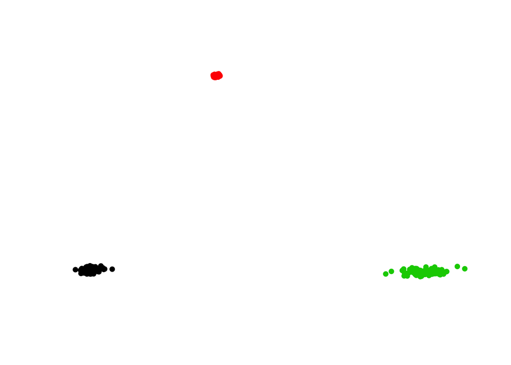

```r
plot(points.sp, col = points.sp@data$id, pch = 16)
```

Everything is looking good, although we just see the points for now. Now that we have the data in the format we want, we are ready to start calculating trajectories.

## 2. Trajectories

What is a trajectory and why is it useful? A trajectory is the path connecting the relocations of a tracked animal. Aspects of the trajectory, such as the distance between each relocation and the direction (angle) of each segment, are very useful for modeling animal movement and testing predictions of hypotheses.

Let’s examine how we can quantify the path, or trajectory of the tracked animals. The function `as.ltraj` in the `adehabitatLT` package makes this easy.

To start, we need to give `as.ltraj` three arguments:

- xy: the coordinates
- date: a POSIXct object with date and (if present) time
- id: a variable to group points based on individual

Note: If you want distances calculated in metres, you should have your coordinates in UTM. For converting between coordinate types, you can use the `spTransform` function.

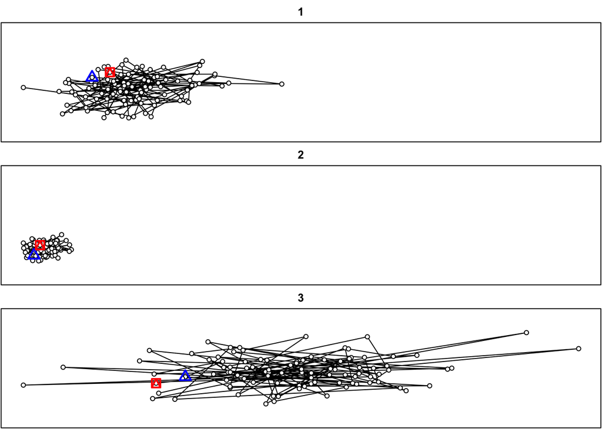

```r
# We need to make sure that date is correctly formatted, and that there is an ID column
data.ltraj <- as.ltraj(xy = points.df[,c("x", "y")],
                       date =  as.POSIXct(points.df$date),
                       id = points.df$id)

plot(data.ltraj)
```

```r
data.ltraj  # bltu.paths is a list.
```

```
##
## *********** List of class ltraj ***********
##
## Type of the traject: Type II (time recorded)
## * Time zone unspecified: dates printed in user time zone *
## Regular traject. Time lag between two locs: 86400 seconds
##
## Characteristics of the bursts:
##   id burst nb.reloc NAs          date.begin            date.end
## 1  1     1      100   0 2017-05-02 19:00:00 2017-08-09 19:00:00
## 2  2     2      100   0 2017-05-02 19:00:00 2017-08-09 19:00:00
## 3  3     3      100   0 2017-05-02 19:00:00 2017-08-09 19:00:00
##
##
##  infolocs provided. The following variables are available:
## [1] "pkey"
```

```r
# Each element of the list is a dataframe for one individual
head(data.ltraj[[1]])  # The trajectory for the first animal
```

```
##          x       y                date        dx         dy      dist
## 1 284938.5 5081423 2017-05-02 19:00:00  59.46459  -3.871277  59.59047
## 2 284997.9 5081419 2017-05-03 19:00:00 -15.69707 -37.623665  40.76688
## 3 284982.2 5081381 2017-05-04 19:00:00 -70.22415  12.149887  71.26746
## 4 284912.0 5081393 2017-05-05 19:00:00  96.19290  23.579096  99.04064
## 5 285008.2 5081417 2017-05-06 19:00:00 130.15066  -1.243448 130.15660
## 6 285138.4 5081416 2017-05-07 19:00:00 -70.86912   8.829045  71.41698
##      dt       R2n    abs.angle rel.angle
## 1 86400     0.000 -0.065010482        NA
## 2 86400  3551.024 -1.966052686 -1.901042
## 3 86400  3637.426  2.970272869 -1.346860
## 4 86400  1561.085  0.240383345 -2.729890
## 5 86400  4896.394 -0.009553623 -0.249937
## 6 86400 40003.915  3.017648864  3.027202
```

The trajectory for each animal measures:

- distance,
- dt (the difference in seconds between relocations),
- R2n (the squared distance between the first relocation of the trajectory and the current relocation), and
- two angle measurements (absolute and relative).

For a complete description of these parameters: https://cran.r-project.org/web/packages/adehabitatLT/vignettes/adehabitatLT.pdf

Now that we have our trajectory object, let’s put it in a more useful format so that we can plot and analyze further. We can combine all the trajectories into one dataframe using a short `for` loop. A loop carries out some code for each element in a sequence. In our case we want to add each element (individual) of the trajectory list together into one dataframe. We also want to add a column that identifies the individual for each movement.

```r
# Create a dataframe to hold all of the contents of bltu.paths with a column for id.
# Put first element into the dataframe
total.path.df <- data.frame(data.ltraj[[1]], id = attr(data.ltraj[[1]], "id"))
# Use a 'for' loop to fill the larger dataframe with the rest of the trajectories.
for(i in 2:length(data.ltraj)) {
  total.path.df <- rbind(total.path.df,
                         data.frame(data.ltraj[[i]], id = attr(data.ltraj[[i]], "id")))
}

# Calculate distance travelled per day and add it to the dataframe
total.path.df$distperday <- total.path.df$dist / (total.path.df$dt/60/60/24)
```

Now we have a dataframe with a row for every relocation, a column for the movement per day in metres, and a column that identifies the individual. We can summarize this data easily using the `aggregate` function and then make a graph using `ggplot` to examine some differences.

```r
# Aggregate to show mean distance per day for each turtle
path.summary <- aggregate(distperday~id, data = total.path.df, FUN = mean)
path.summary$sd <- aggregate(distperday~id, data = total.path.df, FUN = sd)$distperday

# Look at summmary dataframe
path.summary
```

```
##   id distperday        sd
## 1  1   57.13210 36.365348
## 2  2   15.10382  8.447456
## 3  3  107.52623 84.331067
```

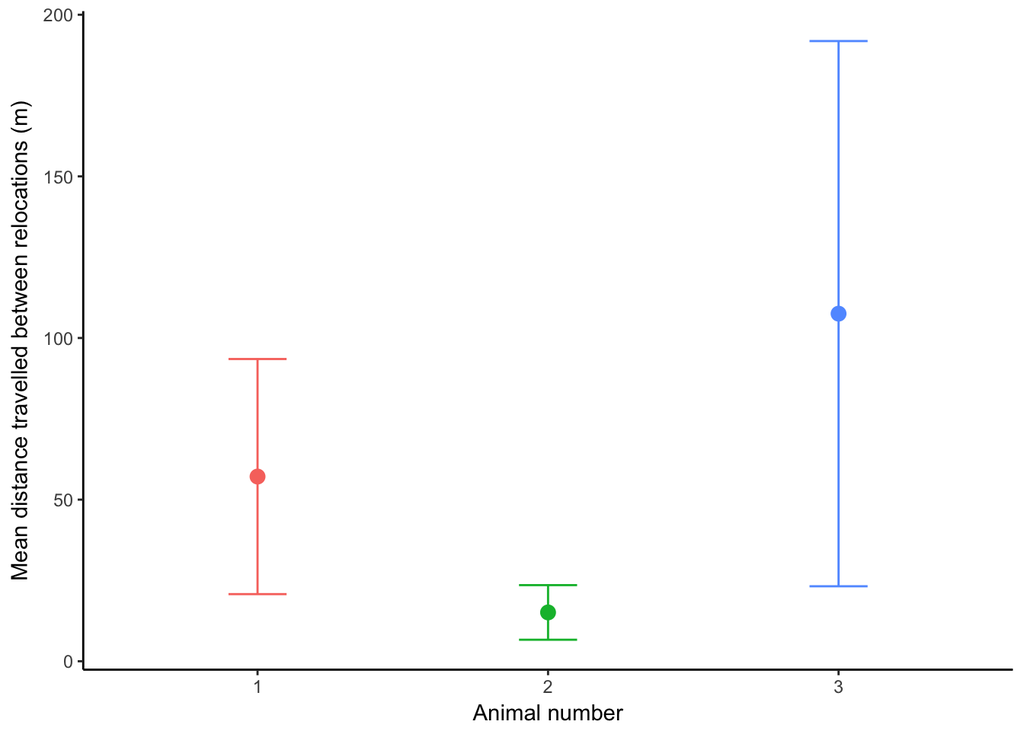

```r
# Make a graph to visualize data using ggplot
# Create limits used for error bars in graph
limits <- aes(ymax = path.summary$distperday + path.summary$sd,
              ymin = path.summary$distperday - path.summary$sd)

# Make plot. Choose the dataframe (data) and aesthetics (aes; for the x and y)
path.plot <- ggplot(data = path.summary, aes(x = id, y = distperday, colour = id)) +
  geom_point(size = 3) + # add points
  geom_errorbar(limits, width = 0.2) + # adds error bars
  labs(x = "Animal number",
       y = "Mean distance travelled between relocations (m)" ) + # Axis labels
  theme_classic() + # Make plot black and white with no background grid
  theme(legend.position = "none")
path.plot # call plot
```

Now we have all the information about paths in an easy to use dataframe that we can join to other information (eg. body size, sex, habitat type) to perform analyses in R. For a more in-depth look at analyzing animal tracks using `adehabitatLT`, check out this tutorial: https://cran.r-project.org/web/packages/adehabitatLT/vignettes/adehabitatLT.pdf

I hope someone finds this useful! In the next post, I will construct home ranges in R with minimum convex polygons and kernels.